# Script2

Maëlie Perier

2024-05-18

## On charge les packages

```r
library(urca)
#library(fUnitRoots)
library(zoo)
library(lubridate)
#install.packages("tseries")
#install.packages("forecast")
library(forecast)
library(tseries)
library(stargazer)
#library(astsa)
library(ellipse)
```

```r
library(ggplot2)
```

## On importe les données - gaz naturel

Ensuite on prend les données de 2000 à 2019 pour éviter les chocs causés par les chocs pétroliers de 1990 ainsi que le Covid-19. On range le df par date puis on le converti en série temporelle

```r
datafile <- "valeurs_mensuelles.csv"
data <- read.csv(datafile, sep = ";", skip = 3, col.names = c("Date", "x1", "ignore"))

data$Date <- as.yearmon(data$Date)
data_filt <- subset(data, Date >= as.yearmon("Jan 2000") & Date <= as.yearmon("Dec 2019"))
data_filt <- data_filt[order(data_filt$Date), ]
data_ts_ <- ts(data_filt$x1, start = data_filt$Date[1], frequency = 12)

data_ts_entiere <- ts(data$x1, start = data$Date[1], frequency = 12)

data_ts <- zoo(data_ts_, order.by = index(data_ts_))
```

## Including Plots

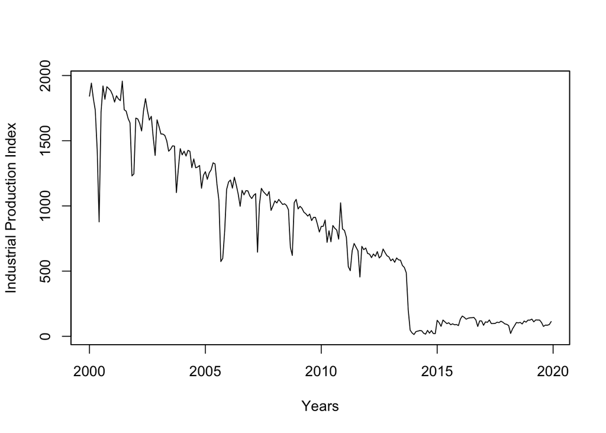

```r
plot(data_ts, xlab="Years", ylab = "Industrial Production Index")
```

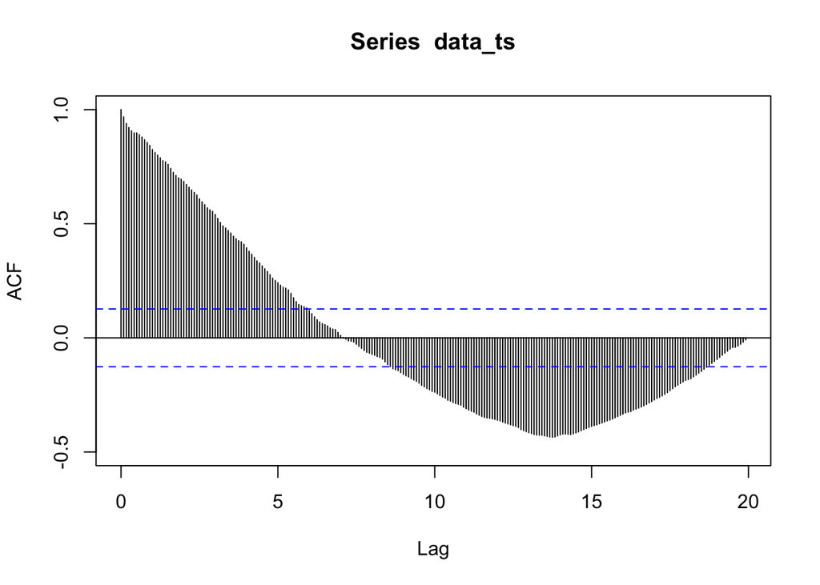

```r
acf(data_ts, 20*12, ylim=c(-0.5, 1))
```

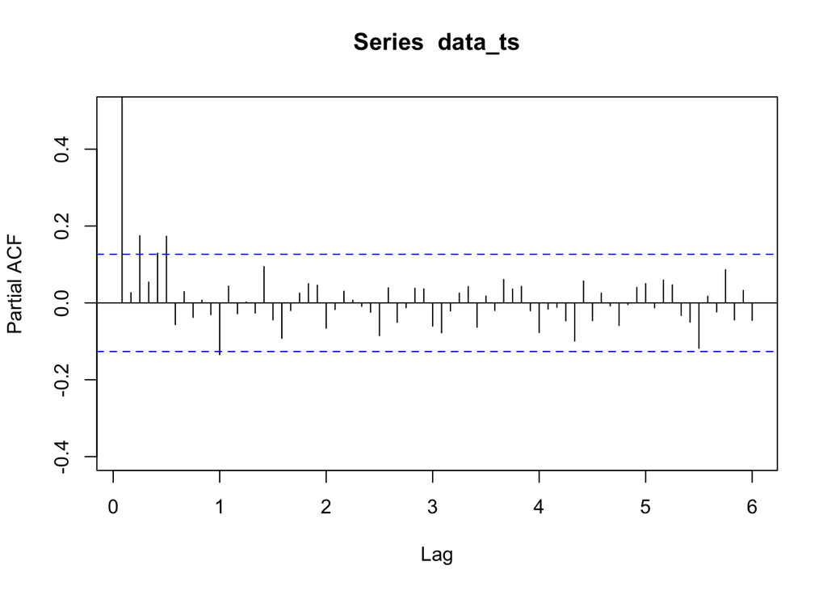

```r
pacf(data_ts, 6*12, ylim=c(-0.4, 0.5))
```

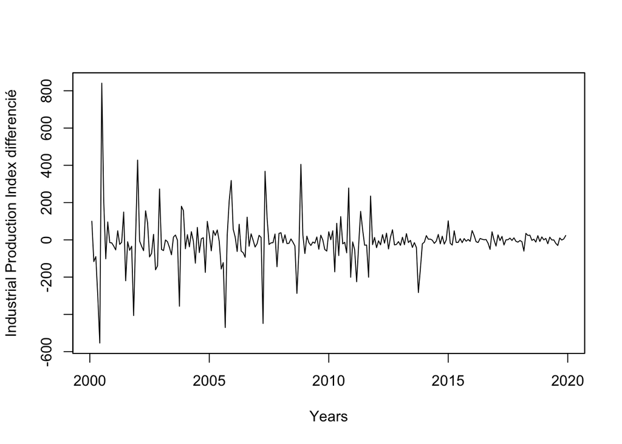

```r
data_ts_diff <- diff(data_ts)
plot(data_ts_diff, xlab="Years", ylab = "Industrial Production Index differencié")
```

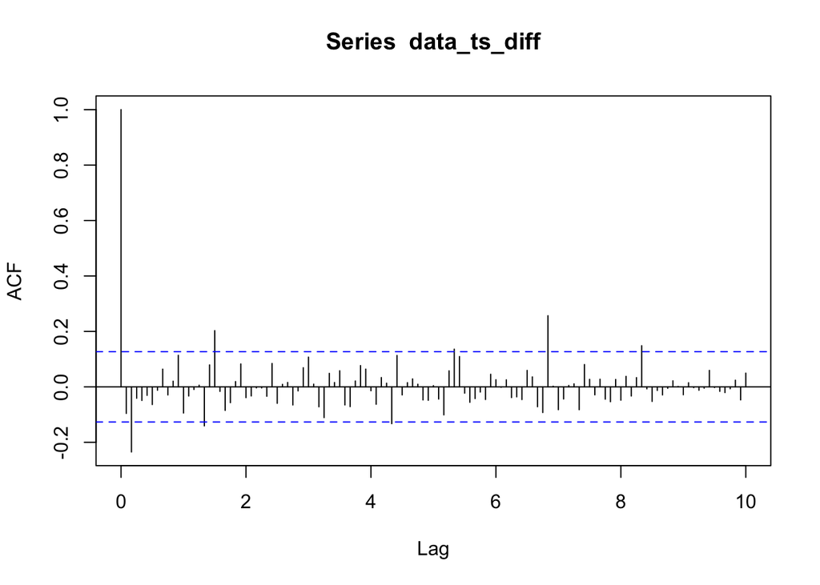

```r
acf(data_ts_diff, 10*12)
```

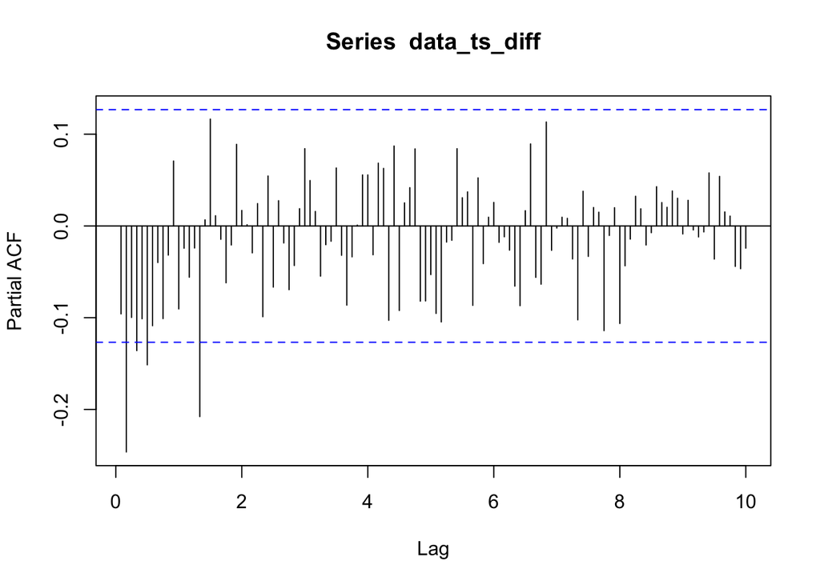

```r
pacf(data_ts_diff, 10*12)
```

```r
qmax <- 7
pmax <- 2
```

La série semble stationnaire, la moyenne semble nulle même si la variance évolue entre avant et après 2013. Nous souhaitons désormais vérifier notre hypothèse de stationarité à l’aide de qqs tests.

```r
adf_test_result <- adf.test(data_ts_diff)
print(adf_test_result)
```

```
##
##  Augmented Dickey-Fuller Test
##
## data:  data_ts_diff
## Dickey-Fuller = -8.7955, Lag order = 6, p-value = 0.01
## alternative hypothesis: stationary
```

```r
pp_result <- pp.test(data_ts_diff)
print(pp_result)
```

```
##
##  Phillips-Perron Unit Root Test
##
## data:  data_ts_diff
## Dickey-Fuller Z(alpha) = -214, Truncation lag parameter = 4, p-value =
## 0.01
## alternative hypothesis: stationary
```

```r
kpss_result <- kpss.test(data_ts_diff)
print(kpss_result)
```

```
##
##  KPSS Test for Level Stationarity
##
## data:  data_ts_diff
## KPSS Level = 0.033042, Truncation lag parameter = 4, p-value = 0.1
```

Les tests confirment qu’on ne peut pas rejeter l’hypothèse de stationarité En regardant les graphiques précédents, il semble qu’on ait pmax = 2 et qmax = 7

On regarde si le modèle ARIMA(2,0,7) est bien ajusté et valide (respectivement que ses coeffs sont significatifs et que ces résidus ne sont pas autocorrélés)

```r
arima207 <- arima(data_ts_diff,c(2,0,7))

signif <- function(estim){
coef <- estim$coef
se <- sqrt(diag(estim$var.coef))
t <- coef/se
pval <- ((1-pnorm(abs(t)))*2)
return(rbind(coef,se,pval))
}
signif(arima207)
```

```
##             ar1         ar2         ma1          ma2       ma3        ma4
## coef 1.40997179 -0.97288156 -1.66552819 1.019292e+00 0.1575098 -0.2997045
## se   0.02265478  0.02152854  0.07046378 1.297994e-01 0.1422397  0.1426195
## pval 0.00000000  0.00000000  0.00000000 3.996803e-15 0.2681404  0.0356035
##              ma5         ma6         ma7     intercept
## coef -0.01621728 -0.04254195 0.003369042 -7.0960569961
## se    0.13893989  0.13128752 0.071939017  2.0650647139
## pval  0.90708070  0.74591041 0.962647193  0.0005898492
```

```r
Box.test(arima207$residuals,lag=15, type="Ljung-Box", fitdf=6)
```

```
##
##  Box-Ljung test
##
## data:  arima207$residuals
## X-squared = 5.1535, df = 9, p-value = 0.8207
```

```r
Qtests <- function(series, k, fitdf=0) {
pvals <- apply(matrix(1:k), 1, FUN=function(l) {
pval <- if (l<=fitdf) NA else Box.test(series, lag=l, type="Ljung-Box", fitdf=fitdf)$p.value
return(c("lag"=l,"pval"=pval))
})
return(t(pvals))
}
Qtests(arima207$residuals, 15, 6)
```

```
##       lag      pval
##  [1,]   1        NA
##  [2,]   2        NA
##  [3,]   3        NA
##  [4,]   4        NA
##  [5,]   5        NA
##  [6,]   6        NA
##  [7,]   7 0.7300584
##  [8,]   8 0.8721644
##  [9,]   9 0.7307147
## [10,]  10 0.7924619
## [11,]  11 0.6956149
## [12,]  12 0.5596388
## [13,]  13 0.6693205
## [14,]  14 0.7635788
## [15,]  15 0.8207249
```

```r
signif <- function(estim){# test des significations individuelles des coefficients
coef <- estim$coef
se <- sqrt(diag(estim$var.coef))
t <- coef/se
pval <- (1-pnorm(abs(t)))*2
return(rbind(coef,pval))
}
for (p in 0:2) {
  for (q in 0:7) {
    print(c(p,q))
    print(signif(arima(data_ts, c(p,0,q), include.mean = FALSE))) }
}
```

```
## [1] 0 0
##
## coef
## pval
## [1] 0 1
##            ma1
## coef 0.9661089
## pval 0.0000000
## [1] 0 2
##           ma1       ma2
## coef 1.516332 0.7845318
## pval 0.000000 0.0000000
## [1] 0 3
##           ma1      ma2       ma3
## coef 1.634932 1.493401 0.7314349
## pval 0.000000 0.000000 0.0000000
## [1] 0 4
##           ma1      ma2      ma3       ma4
## coef 1.535471 1.560052 1.287972 0.6689491
## pval 0.000000 0.000000 0.000000 0.0000000
## [1] 0 5
##          ma1     ma2      ma3      ma4       ma5
## coef 1.47425 1.55762 1.486565 1.138889 0.5706661
## pval 0.00000 0.00000 0.000000 0.000000 0.0000000
## [1] 0 6
##           ma1      ma2      ma3      ma4      ma5          ma6
## coef 1.532185 1.797716 1.801317 1.584986 1.103771 5.111209e-01
## pval 0.000000 0.000000 0.000000 0.000000 0.000000 2.220446e-16
## [1] 0 7
##           ma1      ma2   ma3      ma4      ma5       ma6          ma7
## coef 1.369241 1.407744 1.511 1.478021 1.282019 0.9150131 0.4233934352
## pval 0.000000 0.000000 0.000 0.000000 0.000000 0.0000000 0.0001660552
## [1] 1 0
##            ar1
## coef 0.9938347
## pval 0.0000000
## [1] 1 1
##            ar1         ma1
## coef 0.9961665 -0.17850372
## pval 0.0000000  0.05638633
```

[output cut: 56 more lines]

```
## pval  0.80114756
## [1] 2 6
##            ar1       ar2       ma1           ma2         ma3        ma4
## coef 0.0517495 0.9469276 0.7811983 -4.722630e-01 -0.34309687 -0.1141519
## pval 0.1907587 0.0000000 0.0000000  1.292699e-08  0.00018855  0.1765691
##              ma5         ma6
## coef -0.06746974 -0.03522427
## pval  0.40937528  0.60423539
## [1] 2 7
##             ar1       ar2       ma1           ma2           ma3        ma4
## coef 0.05904644 0.9395394 0.7708821 -4.875386e-01 -0.3534897402 -0.1236528
## pval 0.16843637 0.0000000 0.0000000  9.853310e-09  0.0001473738  0.1560527
##              ma5          ma6        ma7
## coef -0.09456494 -0.002444553 0.05339803
## pval  0.30797788  0.977251468 0.54265277
```

On retient les modèles ARIMA suivant : *ARIMA(0,0,1)* ARIMA(0,0,2) *ARIMA(0,0,3)* ARIMA(0,0,4) *ARIMA(0,0,5)* ARIMA(0,0,6) *ARIMA(0,0,7)* ARIMA(1,0,0) *ARIMA(1,0,2)* ARIMA(2,0,1)

```r
arima_coefs <- list(
  c(0, 0, 1), c(0, 0, 2), c(0, 0, 3),
  c(0, 0, 4), c(0, 0, 5), c(0, 0, 6),
  c(0, 0, 7), c(1, 0, 0), c(1, 0, 2),
  c(2, 0, 1)
)

# Loop through the list of coefficients
valid_arima <- list()
for (coefs in arima_coefs) {
  cat("\nFitting ARIMA(", coefs[1], ",", coefs[2], ",", coefs[3], ") model:\n", sep = "")
  tryCatch({
    model <- arima(data_ts, order = coefs, include.mean = FALSE)
    residuals <- residuals(model)

    # Perform Box-Ljung test on residuals
    box_test <- Box.test(residuals, lag = 15, type = "Ljung-Box", fitdf = sum(coefs))
    cat("\nBox-Ljung Test:\n")
    print(box_test)

    if (box_test$p.value > 0.05) {
      valid_arima <- c(valid_arima, list(coefs))
    }

  })
}
```

```
##
## Fitting ARIMA(0,0,1) model:
##
## Box-Ljung Test:
##
##  Box-Ljung test
##
## data:  residuals
## X-squared = 1754.3, df = 14, p-value < 2.2e-16
##
##
## Fitting ARIMA(0,0,2) model:
##
## Box-Ljung Test:
##
##  Box-Ljung test
##
## data:  residuals
## X-squared = 748.44, df = 13, p-value < 2.2e-16
##
##
## Fitting ARIMA(0,0,3) model:
##
## Box-Ljung Test:
##
##  Box-Ljung test
##
## data:  residuals
## X-squared = 367.79, df = 12, p-value < 2.2e-16
##
##
## Fitting ARIMA(0,0,4) model:
##
## Box-Ljung Test:
##
##  Box-Ljung test
##
## data:  residuals
## X-squared = 237.95, df = 11, p-value < 2.2e-16
##
```

[output cut: 44 more lines]

```
##
##  Box-Ljung test
##
## data:  residuals
## X-squared = 15.191, df = 12, p-value = 0.2312
##
##
## Fitting ARIMA(2,0,1) model:
##
## Box-Ljung Test:
##
##  Box-Ljung test
##
## data:  residuals
## X-squared = 14.664, df = 12, p-value = 0.2604
```

```r
cat("\nList of ARIMA models with Box-Ljung test p-value > 0.05:\n")
```

```
##
## List of ARIMA models with Box-Ljung test p-value > 0.05:
```

```r
for (model in valid_arima) {
  cat("ARIMA(", model[[1]], ",", model[[2]], ",", model[[3]], ")\n", sep = "")
}
```

```
## ARIMA(1,0,2)
## ARIMA(2,0,1)
```

Il nous reste donc plus que deux modèles qui sont à la fois valides et avec des coefficients significatifs : ARIMA(1,0,2) et ARIMA(2,0,1) Arbitrons entre les deux à l’aide des AIC/BIC

```r
aic_12 <- AIC(arima(data_ts, order=c(1,0,2)))
bic_12 <- BIC(arima(data_ts, order=c(1,0,2)))
aic_21 <- AIC(arima(data_ts, order=c(2,0,1)))
bic_21 <- BIC(arima(data_ts, order=c(2,0,1)))

cat("AIC et BIC de l'ARMA(1,2)", aic_12, "/", bic_12,"\nAIC et BIC de l'ARMA(2,1)", aic_21, "/", bic_21)
```

```
## AIC et BIC de l'ARMA(1,2) 2984.384 / 3001.788
## AIC et BIC de l'ARMA(2,1) 2987.243 / 3004.647
```

Les AIC et BIC de l’ARMA(1,2) sont légèrement plus faibles, on opte donc pour ce modèle là.

### Question 5

$$\Delta Z_t =: X_t = \phi_1 X_{t-1} + \epsilon_t + \psi_1 \epsilon_{t-1}
+ \psi_2 \epsilon_{t-2}$$

hence

$$(1 - \phi_1 B)X_t = (1 + \psi_1 B + \psi_2 B^2) \epsilon_t$$

which gives

$$(1 - \phi_1 B)(1 - B)Z_t = (1 + \psi_1 B + \psi_2 B^2) \epsilon_t$$

Replacing the $\phi_1, \psi_1, \psi_2$ by the estimated coefficients (that we obtained earlier), we get

or

$$Z_t = 1.5 Z_{t-1} - 0.50 Z_{t-2} + \epsilon_t + 0.74 \epsilon_{t-1} -
0.36 \epsilon_{t-2}$$